# Project 1: Wrangling, Exploration, Visualization

SDS322E

## Data Wrangling, Exploration, Visualization

### Mindy Tran, mt37643

#### Introduction

Death by drug overdose is a problem that continues to take the lives of many individuals each day. Nearly 70% of all overdoses involves opioids (CDC). The dispensing of opioids is a topic that I am heavily interested in as it has become a prevalent issue in the healthcare industry. Roughly 24% of individuals prescribed opioids for chronic pain misuse them (CDC). In this project, two datasets obtained from the CDC will be used to examine relationships, if any, between (documented) opioid dispensing rate and drug overdose death rates in each state and D.C. It is predicted that there will be a linear relationship between opioid dispensing rate and deaths by drug overdose in each location.

```r
library(tidyverse)
overdose <- read.csv("overdose.csv")
opioid <- read.csv("opioid dispensing .csv")
```

#### Tidying: Reshaping

The tidying of this project was done in the wrangling section to rearrange summary statistics. After finding the summary statistic for the mean and standard deviation of the number of deaths when the opioid dispensing rate is above/below 50, pivot longer was used to organize the data into three columns, ‘Opioid.Dispensing.Rate.per.100 > 50’, ‘name’, and ‘Number of Deaths’. Then, pivot wider was used to organize the data into two rows, ‘mean’ and ‘sd’, with three columns, ‘name’, ‘FALSE’, and ‘TRUE’.

#### Joining/Merging

```r
opioid_overdose <- inner_join(overdose, opioid, by = c(Location = "State"))
overdose %>% n_distinct()
```

```
## [1] 51
```

```r
opioid %>% n_distinct()
```

```
## [1] 52
```

#### Wrangling

```r
opioid_overdose %>% group_by(Location) %>% arrange(desc(Number.of.Deaths))
```

```
## # A tibble: 51 x 6
## # Groups:   Location [51]
##    Location Range.Category Age.adjusted.Ra… Number.of.Deaths Abbreviation
##    <fct>    <fct>                     <dbl>            <int> <fct>
##  1 Califor… 13.6 to 16.0               15               6198 CA
##  2 Florida  21.1 to 57.0               25.5             5268 FL
##  3 Pennsyl… 21.1 to 57.0               35.6             4377 PA
##  4 Ohio     21.1 to 57.0               38.3             4251 OH
##  5 New York 16.1 to 18.5               18.2             3617 NY
##  6 Texas    6.9 to 11.0                10.8             3136 TX
##  7 New Jer… 21.1 to 57.0               31.7             2805 NJ
##  8 Illinois 21.1 to 57.0               21.9             2790 IL
##  9 Michigan 21.1 to 57.0               24.4             2385 MI
## 10 Maryland 21.1 to 57.0               38.2             2369 MD
## # … with 41 more rows, and 1 more variable:
## #   Opioid.Dispensing.Rate.per.100 <dbl>
```

```r
opioid_overdose %>% group_by(Location) %>% select(Location, Opioid.Dispensing.Rate.per.100) %>%
    arrange(desc(Opioid.Dispensing.Rate.per.100))
```

```
## # A tibble: 51 x 2
## # Groups:   Location [51]
##    Location       Opioid.Dispensing.Rate.per.100
##    <fct>                                   <dbl>
##  1 Alabama                                  85.8
##  2 Arkansas                                 80.9
##  3 Louisiana                                74.6
##  4 Tennessee                                74.6
##  5 Kentucky                                 72.3
##  6 Mississippi                              67
##  7 Oklahoma                                 66
##  8 Kansas                                   63.7
##  9 Indiana                                  60.4
## 10 South Carolina                           60.4
## # … with 41 more rows
```

```r
opioid_overdose %>% select(Location, Opioid.Dispensing.Rate.per.100) %>%
    filter(Opioid.Dispensing.Rate.per.100 > 50) %>% count()
```

```
##    n
## 1 20
```

```r
opioid_overdose %>% mutate(Deaths.per.100000 = ((Age.adjusted.Rate/100) *
    1e+05))
```

```
##                Location Range.Category Age.adjusted.Rate Number.of.Deaths
## 1               Alabama   16.1 to 18.5              16.3              768
## 2                Alaska   16.1 to 18.5              17.8              132
## 3               Arizona   21.1 to 57.0              26.8             1907
## 4              Arkansas   11.1 to 13.5              13.5              388
## 5            California   13.6 to 16.0              15.0             6198
## 6              Colorado   16.1 to 18.5              18.0             1079
## 7           Connecticut   21.1 to 57.0              34.7             1214
## 8              Delaware   21.1 to 57.0              48.0              435
## 9  District of Columbia   21.1 to 57.0              43.2              311
## 10              Florida   21.1 to 57.0              25.5             5268
## 11              Georgia   11.1 to 13.5              13.1             1408
## 12               Hawaii   13.6 to 16.0              15.9              242
## 13                Idaho   13.6 to 16.0              15.1              265
## 14             Illinois   21.1 to 57.0              21.9             2790
```

[output cut: 16 more lines]

```r
opioid_overdose %>% mutate(Range.Category = str_replace(Range.Category,
    "[a-zA-Z]+", "\\-")) %>% glimpse()
```

```
## Rows: 51
## Columns: 6
## $ Location                       <fct> Alabama, Alaska, Arizona, Arkansas, Ca…
## $ Range.Category                 <chr> "16.1 - 18.5", "16.1 - 18.5", "21.1 - …
## $ Age.adjusted.Rate              <dbl> 16.3, 17.8, 26.8, 13.5, 15.0, 18.0, 34…
## $ Number.of.Deaths               <int> 768, 132, 1907, 388, 6198, 1079, 1214,…
## $ Abbreviation                   <fct> AL, AK, AZ, AR, CA, CO, CT, DE, DC, FL…
## $ Opioid.Dispensing.Rate.per.100 <dbl> 85.8, 39.1, 44.1, 80.9, 30.9, 40.0, 40…
```

```r
opioid_overdose %>% summarize(mean = mean(Age.adjusted.Rate),
    sd = sd(Age.adjusted.Rate), n_distinct(Age.adjusted.Rate),
    min(Age.adjusted.Rate), max(Age.adjusted.Rate), n = n(),
    se = sd/sqrt(n))
```

```
##       mean       sd n_distinct(Age.adjusted.Rate) min(Age.adjusted.Rate)
## 1 23.13922 10.18401                            50                    8.7
##   max(Age.adjusted.Rate)  n       se
## 1                   52.8 51 1.426046
```

```r
opioid_overdose %>% summarize(mean = mean(Number.of.Deaths),
    sd = sd(Number.of.Deaths), n_distinct(Number.of.Deaths),
    min(Number.of.Deaths), max(Number.of.Deaths), n = n(), se = sd/sqrt(n))
```

```
##       mean       sd n_distinct(Number.of.Deaths) min(Number.of.Deaths)
## 1 1384.902 1407.559                           51                    79
##   max(Number.of.Deaths)  n       se
## 1                  6198 51 197.0976
```

```r
opioid_overdose %>% summarize(mean = mean(Opioid.Dispensing.Rate.per.100),
    sd = sd(Opioid.Dispensing.Rate.per.100), n_distinct(Opioid.Dispensing.Rate.per.100),
    min(Opioid.Dispensing.Rate.per.100), max(Opioid.Dispensing.Rate.per.100),
    n = n(), se = sd/sqrt(n))
```

```
##       mean       sd n_distinct(Opioid.Dispensing.Rate.per.100)
## 1 49.53137 13.05296                                         47
##   min(Opioid.Dispensing.Rate.per.100) max(Opioid.Dispensing.Rate.per.100)  n
## 1                                30.3                                85.8 51
##        se
## 1 1.82778
```

```r
opioid_overdose %>% summarize_all(function(x) sum(is.na(x)))
```

```
##   Location Range.Category Age.adjusted.Rate Number.of.Deaths Abbreviation
## 1        0              0                 0                0            0
##   Opioid.Dispensing.Rate.per.100
## 1                              0
```

```r
opioid_overdose %>% group_by(Location, Abbreviation) %>% summarize(opioid.dispensing.per.100000 = ((Opioid.Dispensing.Rate.per.100/100) *
    1e+05))
```

```
## # A tibble: 51 x 3
## # Groups:   Location [51]
##    Location             Abbreviation opioid.dispensing.per.100000
##    <fct>                <fct>                               <dbl>
##  1 Alabama              AL                                 85800
##  2 Alaska               AK                                 39100
##  3 Arizona              AZ                                 44100
##  4 Arkansas             AR                                 80900
##  5 California           CA                                 30900
##  6 Colorado             CO                                 40000
##  7 Connecticut          CT                                 40500
##  8 Delaware             DE                                 51600
##  9 District of Columbia DC                                 39900
## 10 Florida              FL                                 45400.
## # … with 41 more rows
```

```r
opioid_overdose %>% group_by(Range.Category) %>% summarize(n())
```

```
## # A tibble: 6 x 2
##   Range.Category `n()`
##   <fct>          <int>
## 1 11.1 to 13.5       4
## 2 13.6 to 16.0      10
## 3 16.1 to 18.5       6
## 4 18.6 to 21.0       2
## 5 21.1 to 57.0      26
## 6 6.9 to 11.0        3
```

```r
opioid_overdose %>% group_by(Abbreviation) %>% summarize(n())
```

```
## # A tibble: 51 x 2
##    Abbreviation `n()`
##    <fct>        <int>
##  1 AK               1
##  2 AL               1
##  3 AR               1
##  4 AZ               1
##  5 CA               1
##  6 CO               1
##  7 CT               1
##  8 DC               1
##  9 DE               1
## 10 FL               1
## # … with 41 more rows
```

```r
opioid_overdose %>% group_by(Location) %>% summarize(n())
```

```
## # A tibble: 51 x 2
##    Location             `n()`
##    <fct>                <int>
##  1 Alabama                  1
##  2 Alaska                   1
##  3 Arizona                  1
##  4 Arkansas                 1
##  5 California               1
##  6 Colorado                 1
##  7 Connecticut              1
##  8 Delaware                 1
##  9 District of Columbia     1
## 10 Florida                  1
## # … with 41 more rows
```

```r
table1 <- opioid_overdose %>% group_by(Opioid.Dispensing.Rate.per.100 >
    50) %>% summarize(mean = mean(Number.of.Deaths), sd = sd(Number.of.Deaths)) %>%
    pivot_longer(-1, values_to = "Number of Deaths") %>% pivot_wider(names_from = "Opioid.Dispensing.Rate.per.100 > 50",
    values_from = "Number of Deaths")

library(gt)
table1 %>% gt %>% tab_header(title = md("**Summary Statistics**"),
    subtitle = md("opioid dispensing rate > 50")) %>% tab_spanner(label = "Variables",
    columns = c("name", "FALSE", "TRUE"))
```

**Summary Statistics**

opioid dispensing rate > 50

| Variables name | Variables FALSE | Variables TRUE |
| --- | --- | --- |
| mean | 1492.742 | 1217.7500 |
| sd | 1628.343 | 989.3305 |

To find which location had the highest opioid dispensing rate and the most deaths by drug overdose, ‘opioid_overdose’ was grouped by location and arranged in descending order by ‘Number.of.Deaths’ and ‘Opioid.Dispensing.Rate.per.100’, respectively. California has the highest number of deaths by drug overdose, and Alabama has the highest opioid dispensing rate. To find out how many locations had a dispensing rate over 50, select was used to narrow down the dataset to just ‘Location’ and ‘Opioid.Dispensing.Rate.per.100’. Filter was used to find ‘Opioid.Dispensing.Rate.per.100>50’, and count was used to tally up the number of locations that had a dispensing rate over 50, which was 20 locations. Mutate was used to generate a variable, called ‘Deaths.per.100000’, that is a function of ‘Age.adjusted.Rate’, by dividing ‘Age.adjusted.Rate’ by 100 and mulitplying it by 100,000 to find the number of deaths per 100,000 people at each location. Mutate was used again with a `stringr` function, ‘str_replace’, inside of it to change ‘to’ to ‘-’ in the ‘Range.Category’ variable using regex.

To compute summary statistics, the dataset was summarized by the mean, sd, n_distinct, min, max, n, and se of each numeric variable. The mean age adjusted death rate is around 23 with a sd of around 10. The mean number of deaths is around 1384 and the sd is around 1407. The mean opioid dispensing rate is around 50 and the sd is around 13. To find the number of missing values for each variable, a function was created in summarize to find the sum of is.na for each variable. Summarize was used to generate a variable, called ‘opioid.dispensing.per.100000’, that is a function of ‘Opioid.Dispensing.Rate.per.100’, by dividing it by 100 and mulitplying it by 100,000 to find the opioid dispensing rate per 100,000 people at each location. The dataset was also, seperately, grouped by each categorical variable to find the counts of each variable by putting n() inside summarize. To find the mean and sd of number of deaths when the opioid dispensing rate is above/below 50, the dataset was grouped by ‘Opioid.Dispensing.Rate.per.100>50’ and summarized by the mean and sd of ‘Number.of.Deaths’. The mean and sd of the number of deaths when the opioid dispensing rate is less than 50 is around 1493 and 1628 people, respectively, and, when the opioid dispensing rate is greater than 50, the mean and sd is around 1218 and 989 people, respectively.

#### Visualizing

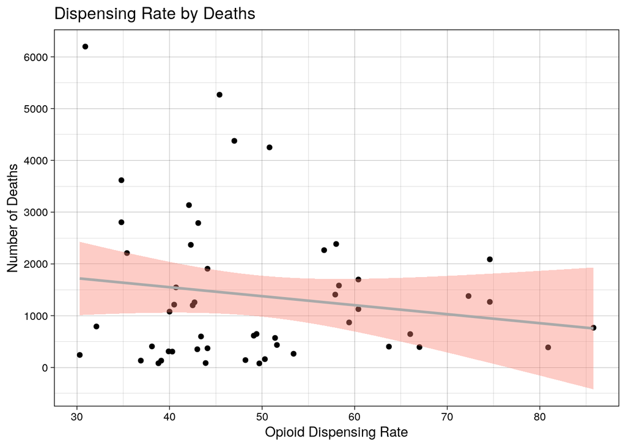

```r
ggplot(opioid_overdose, aes(Opioid.Dispensing.Rate.per.100, Number.of.Deaths)) +
    ylab("Number of Deaths") + xlab("Opioid Dispensing Rate") +
    ggtitle("Dispensing Rate by Deaths") + geom_point() + geom_smooth(method = "lm",
    color = "dark gray", fill = "salmon") + scale_y_continuous(breaks = seq(0,
    6000, 1000)) + theme_linedraw()
```

This plot depicts the relationship between opioid dispensing rate and number of deaths with a regression line running across the plot. As seen in the plot, there is no correlation between number of deaths and opioid dispensing rate as the regression line shows no apparent trend. The number of deaths is scattered across all opioid dispensing rate with no distinct pattern. Though, it can be seen that the number of deaths at most of the locations is below 2000 people.

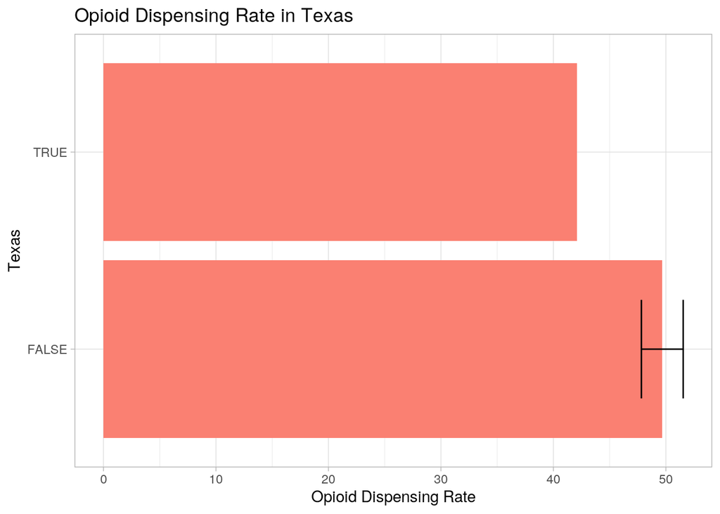

```r
ggplot(opioid_overdose, aes(x = Opioid.Dispensing.Rate.per.100,
    y = Location == "Texas")) + xlab("Opioid Dispensing Rate") +
    ylab("Texas") + ggtitle("Opioid Dispensing Rate in Texas") +
    geom_bar(stat = "summary", fill = "salmon") + geom_errorbar(stat = "summary",
    width = 0.5) + theme_light()
```

The plot depicts the opioid dispensing rate in Texas compared to all of the other locations. The opioid dispensing rate in Texas is relatively lower than the rest of the locations. All of the other locations combined have an average opioid dispensing rate close to 50 people per 100 people with a standard error of around 2, whereas Texas has an opioid dispensing rate of around 42 people per 100 people.

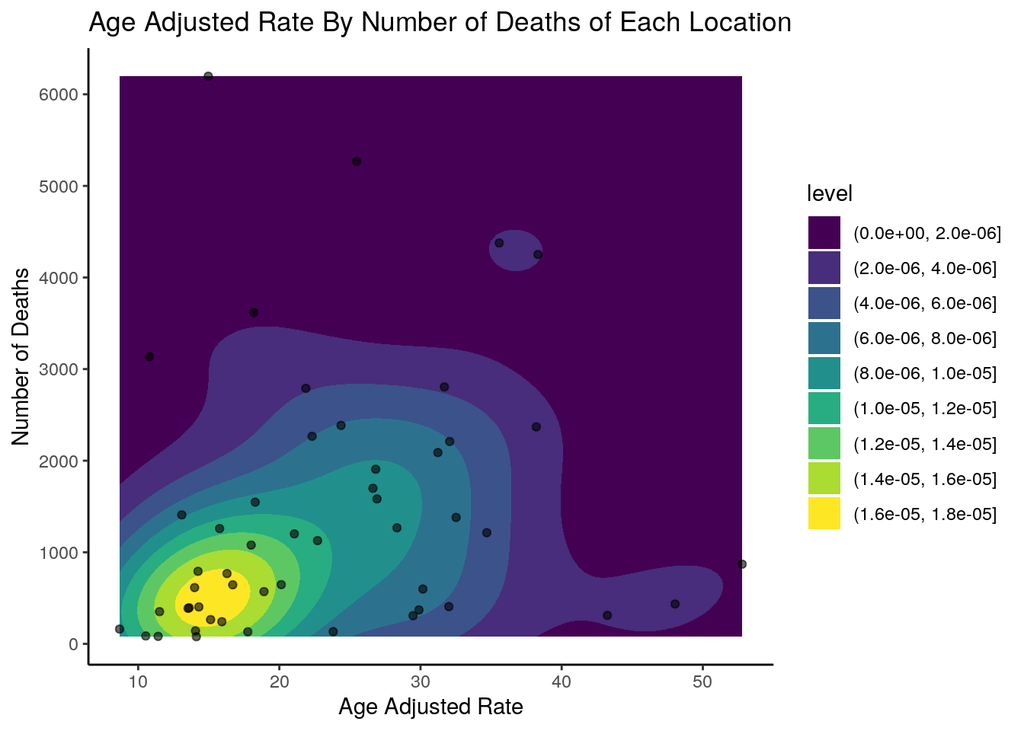

```r
ggplot(opioid_overdose, aes(Age.adjusted.Rate, Number.of.Deaths)) +
    xlab("Age Adjusted Rate") + ylab("Number of Deaths") + ggtitle("Age Adjusted Rate By Number of Deaths of Each Location") +
    geom_density2d_filled() + geom_jitter(alpha = 0.6) + scale_y_continuous(breaks = seq(0,
    6000, 1000)) + theme_classic()
```

The plot depicts the distribution of the age adjusted death rate and number of deaths, where the points represents the age adjusted death rate and number of deaths at each location. The points are most heavily concentration towards the left corner of the plot. The yellow region represents where the concentration of age adjusted death rate and number of deaths is the highest, which occurs when the age adjusted rate is in the range of 12-18 and the number of deaths is in the range of 500 to 800 people. It can be seen that the age adjusted rate spans across a range of values from 5 to 55, and the number of deaths for most of the locations is between the range of 50 to 3000 people.

#### Concluding Remarks

According to the findings, there appears to be no relationship between opioid dispensing rates and number of deaths by drug overdose; however, the data obtained does not account for opioid dispensing through other means besides prescription.